# Statistical Inference Project II

Xinli

May 19, 2016

**1. Load the ToothGrowth data and perform some basic exploratory data analyses**

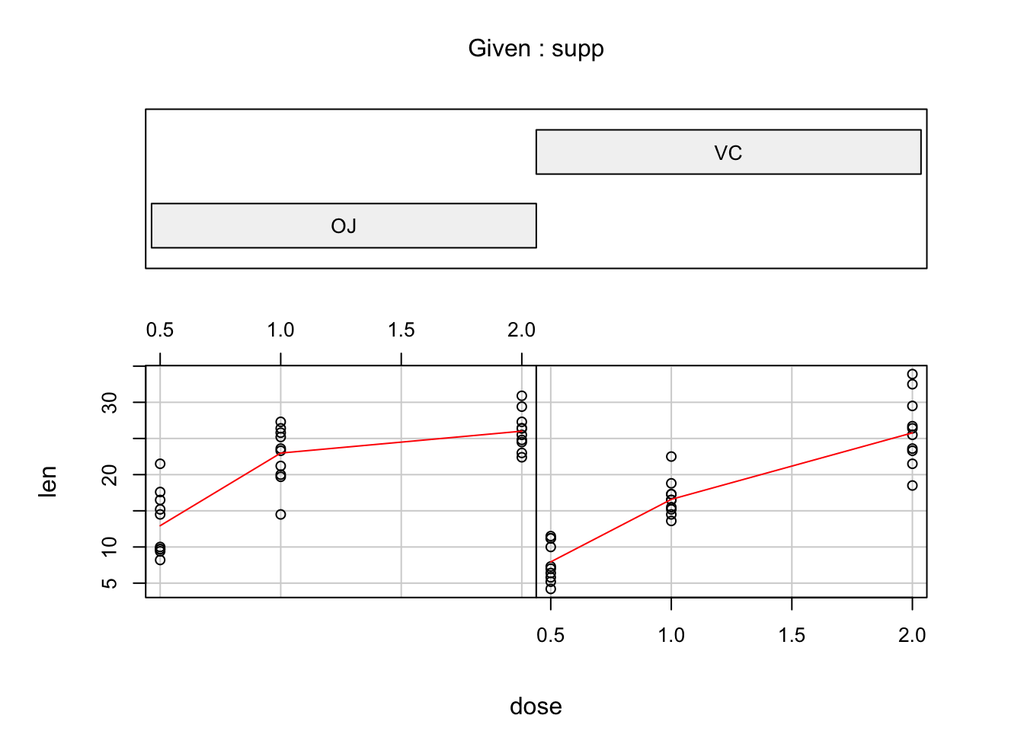

```r
library(datasets)
data(ToothGrowth)
require(graphics)
coplot(len ~ dose | supp, data = ToothGrowth, panel = panel.smooth,
      xlab = "dose")
```

**2. Provide a basic summary of the data.**

```r
summary(ToothGrowth)
```

```
##       len        supp         dose
##  Min.   : 4.20   OJ:30   Min.   :0.500
##  1st Qu.:13.07   VC:30   1st Qu.:0.500
##  Median :19.25           Median :1.000
##  Mean   :18.81           Mean   :1.167
##  3rd Qu.:25.27           3rd Qu.:2.000
##  Max.   :33.90           Max.   :2.000
```

```r
table(ToothGrowth$dose, ToothGrowth$supp)
```

```
##
##       OJ VC
##   0.5 10 10
##   1   10 10
##   2   10 10
```

**3. Use confidence intervals and/or hypothesis tests to compare tooth growth by supp and dose.**

Comparing tooth growth by supplements:

```r
OJ=ToothGrowth$len[ToothGrowth$supp=="OJ"]
VC=ToothGrowth$len[ToothGrowth$supp=="VC"]
t.test(OJ,VC)
```

```
##
##  Welch Two Sample t-test
##
## data:  OJ and VC
## t = 1.9153, df = 55.309, p-value = 0.06063
## alternative hypothesis: true difference in means is not equal to 0
## 95 percent confidence interval:
##  -0.1710156  7.5710156
## sample estimates:
## mean of x mean of y
##  20.66333  16.96333
```

Comparing tooth growth by dose:

```r
t.test(len~dose, data=ToothGrowth[ToothGrowth$dose %in% c(0.5,1),])$p.value
```

```
## [1] 1.268301e-07
```

```r
t.test(len~dose, data=ToothGrowth[ToothGrowth$dose %in% c(0.5,2),])$p.value
```

```
## [1] 4.397525e-14
```

```r
t.test(len~dose, data=ToothGrowth[ToothGrowth$dose %in% c(1,2),])$p.value
```

```
## [1] 1.90643e-05
```

Under Bonferroni correction, there are 3 tests. So adjuested alpha = alpha/3 = 0.0167. All the p values of t tests are less than adjuested alpha. So the null hypothesis is rejected. That is to say, the increase in dose leads to increase in tooth length.

**4. State your conclusions and the assumptions needed for your conclusions.**

Conclusions:

1. Supplement types have no effect on tooth length.
2. The increase in dose leads to increase in tooth length.

Assumptions:

1. The experiment was done randomized.
2. The samples could represent the population.
3. For t-tests, variances are assumed to be different.